# R Notebook

```r
install.packages("forecast")
install.packages("ggplot2")
install.packages("car")
install.packages("fGarch")
install.packages("quantmod")
install.packages("zoo")
```

```r
library(forecast)
library(ggplot2)
library(car)
library(fGarch)
library(quantmod)
library(zoo)
```

```r
head(nvidia)
```

```
           NVDA.Open NVDA.High NVDA.Low NVDA.Close NVDA.Volume NVDA.Adjusted
2007-01-03  0.617833  0.625333 0.579833   0.601333  1154820000     0.5512931
2007-01-04  0.599167  0.601333 0.583833   0.598500   797298000     0.5486957
2007-01-05  0.584333  0.586667 0.557000   0.561000  1243344000     0.5143162
2007-01-08  0.563000  0.576000 0.553333   0.565167   657270000     0.5181363
2007-01-09  0.566000  0.569833 0.553500   0.554167   764166000     0.5080519
2007-01-10  0.548333  0.586667 0.540000   0.581500  1108746000     0.5331104
```

```r
nrow(nvidia)
```

```
[1] 4873
```

Analisarei os preços da ação da NVIDIA publicados através do Yahoo Finances. Tenho no total cerca de 4873 dias de preços de ações.

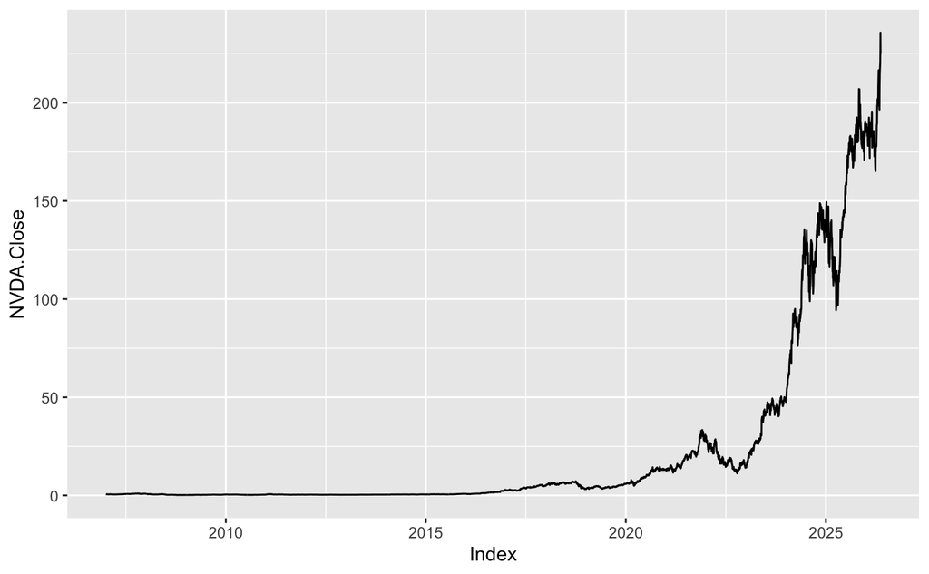

Figura 1 - Preço das ações da NVIDIA de 2007 até hoje.

Nota-se um aumento ao longo da pandemia - a partir de 2020, além de uma subida significativa atribuída ao uso de GPUs vendidos por eles para treinamento de lar- ge language models (chat gpt e outros).

Calculo o log retorno, valor que verifica a dependência linear da mudança de preço ao longo do tempo. Ele mostra se o retorno do passado pode predizer a direção futura das movimentações de preço.

```r
lr <- diff(log(nvidia$NVDA.Close))
lr[1]<-0
```

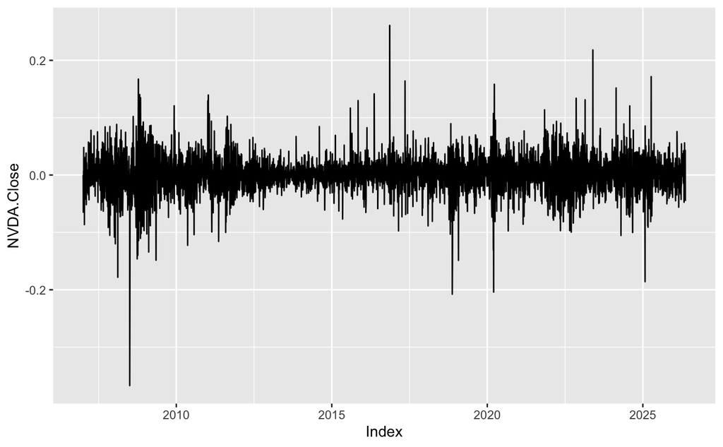

Figura 2 - Gráfico da série de log retorno dos preços das ações da NVIDIA.

O gráfico do log retorno apresenta uma forma/distribuição semelhante a de um ruído branco. Com isso, conclui-se que o processo é estacionário.

Analisaremos o comportamento da função de autocorrelação para o log retorno (tanto o valor normal como ao quadrado).

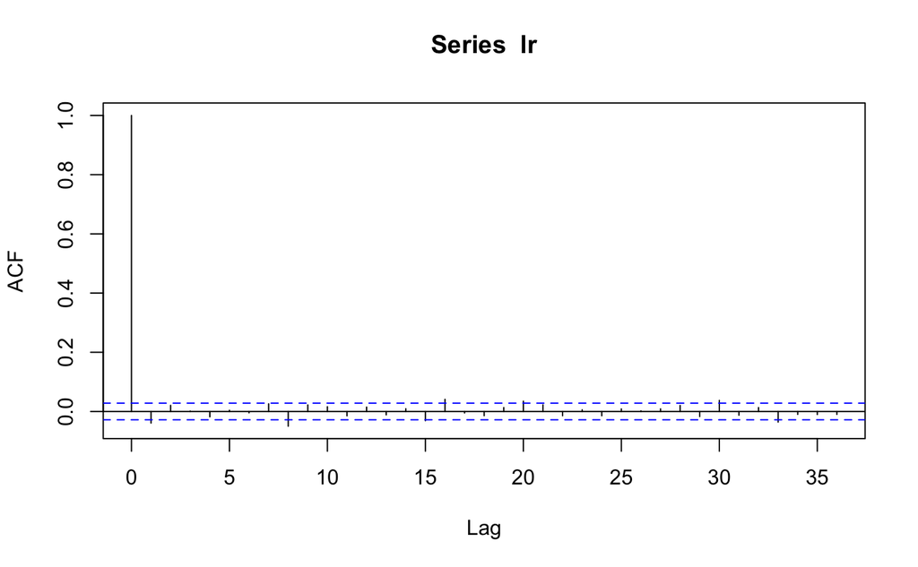

```r
acf(lr)
```

Figura 3 - Gráfico da função de autocorrelação do log retorno.

A Figura 3 apresenta o gráfico da função de autocorrelação para o log retorno. Nela vemos o lag 1 como significativo, seguido de alguns picos isolados nos lags 8, 16, 20 e 30. Vale destacar que o lag 20 refere-se aproximadamente ao período de 1 mês corrido.

É muito difícil prever o retorno diariamente, sendo assim difícil de encontrar dependência com valores passados que apontem a direção (positiva ou negativa) do valor do retorno futuro.

O pequeno pico no lag 1 demonstra que o log retorno de hoje depende do log retorno de ontem. Dado que temos cerca de 4873 dias de preços de ações é comum que o intervalo de confiança fique mais estreito e valores baixos de correlação possam parecer estatisticamente relevantes.

Dos 36 lags calculados é esperado que cerca de 2 apresentem valores significativos ao acaso.

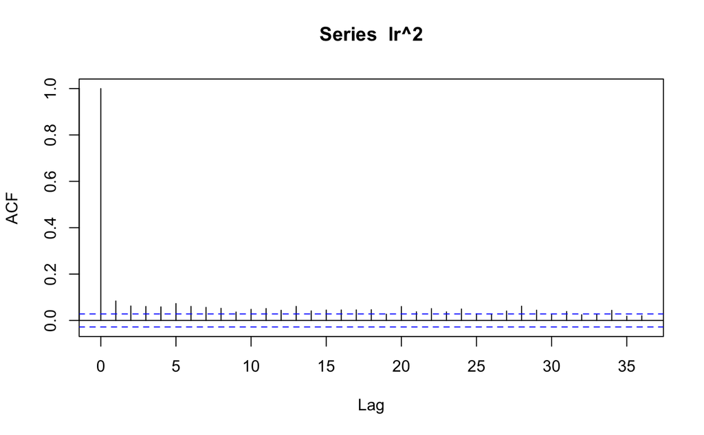

```r
acf(lr^2)
```

Figura 4 - Gráfico da função de autocorrelação do log retorno ao quadrado.

Ao aplicar a potência de 2 aos lags, nota-se que praticamente todos eles ficam com valores significantes, demonstrando autocorrelações positivas que tendem a diminuir lentamente ao longo dos demais lags.

Geralmente, para séries financeiras, o retorno não tem variância condicional constante e altos períodos de volatilidade tendem a ser agrupados. Ou seja, existe uma dependência forte em picos de variação do retorno baseado em seu histórico.

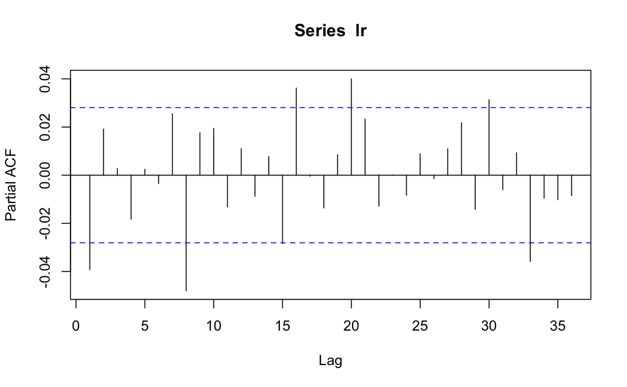

```r
pacf(lr)
```

Figura 5 - Gráfico da função de autocorrelação parcial do log retorno.

Com base nesses dados, proponho um modelo APARCH(p,q), sendo p=1 e q=0 - logo APARCH(1,0), para modelar o comportamento da série de log retorno das ações da NVIDIA, usando a distribuição condicional t-student padronizada e assimétrica.

A premissa adotada é que a volatilidade vista na Figura 4 é assimétrica, ou seja, informação negativa gera muito mais volatilidade do que informação positiva, mantida a mesma magnitude. Além disso, esse tipo de modelo é bastante utilizado para previsão de comportamento de preços de ações.

Após avaliação dos resíduos padronizados quadrados, nota-se que o modelo com parâmetros p=1 e q=0 falha no teste Ljung-Box R^2. Sendo assim, é feita uma nova proposta de modelo, com parâmetros p=2 e q=0.

```r
aparch_model <- garchFit(formula = ~aparch(2,0), lr, include.mean = TRUE,
                        cond.dist = "sstd", trace = FALSE)
summary(aparch_model)
```

```
Title:
 GARCH Modelling

Call:
 garchFit(formula = ~aparch(2, 0), data = lr, cond.dist = "sstd",
    include.mean = TRUE, trace = FALSE)

Mean and Variance Equation:
 data ~ aparch(2, 0)
<environment: 0x7ff74528bcd8>
 [data = lr]

Conditional Distribution:
 sstd

Coefficient(s):
       mu      omega     alpha1     alpha2     gamma1     gamma2      delta       skew      shape
0.0013141  0.0275471  0.2218366  0.2584380  0.3140147  0.2293553  0.9083915  0.9851056  4.1302571

Std. Errors:
 based on Hessian

Error Analysis:
        Estimate  Std. Error  t value Pr(>|t|)
mu     0.0013141   0.0002959    4.440 8.99e-06 ***
omega  0.0275471   0.0010586   26.022  < 2e-16 ***
alpha1 0.2218366   0.0240584    9.221  < 2e-16 ***
alpha2 0.2584380   0.0274575    9.412  < 2e-16 ***
gamma1 0.3140147   0.0810316    3.875 0.000107 ***
gamma2 0.2293553   0.0681404    3.366 0.000763 ***
delta  0.9083915   0.1378772    6.588 4.45e-11 ***
skew   0.9851056   0.0178093   55.314  < 2e-16 ***
shape  4.1302571   0.2566471   16.093  < 2e-16 ***
---
Signif. codes:  0 ‘***’ 0.001 ‘**’ 0.01 ‘*’ 0.05 ‘.’ 0.1 ‘ ’ 1

Log Likelihood:
 10656.34    normalized:  2.186814

Description:
 Thu May 21 08:48:01 2026 by user:



Standardised Residuals Tests:
                                   Statistic    p-Value
 Jarque-Bera Test   R    Chi^2  1.529985e+04 0.00000000
 Shapiro-Wilk Test  R    W      9.413871e-01 0.00000000
 Ljung-Box Test     R    Q(10)  1.251931e+01 0.25180259
 Ljung-Box Test     R    Q(15)  1.885771e+01 0.22025457
 Ljung-Box Test     R    Q(20)  2.935249e+01 0.08104717
 Ljung-Box Test     R^2  Q(10)  1.685504e+01 0.07763378
 Ljung-Box Test     R^2  Q(15)  2.286547e+01 0.08703834
 Ljung-Box Test     R^2  Q(20)  3.211351e+01 0.04210368
 LM Arch Test       R    TR^2   1.996064e+01 0.06783411

Information Criterion Statistics:
      AIC       BIC       SIC      HQIC
-4.369933 -4.357944 -4.369940 -4.365726
```

O modelo apresenta a relação das estatísticas geradas - parâmetros estimados, com seus respectivos erros padrão, t-value e relevância estatística. Testes são aplicados adotando um intervalo de confiança de 95%. Destaca-se que todos os parâmetros são estatisticamente relevantes, pois a probabilidade de encontrar um valor maior que o t-value obtido é menor que 0.05.

Além disso, são apresentados os testes dos resíduos padronizados. O teste de hipó- tese de Ljung-Box tem como Null Hypothesis a premissa que não existe autocorrelação nos resíduos - os dados são distribuídos independentemente. Um p-value > 0.05 é um bom sinal para o modelo, pois não rejeita a Null Hypothesis. Sendo assim, espera-se que tanto os valores de R e R^2 não rejeitem a Null Hypothesis. Analisan- do os resultados nos lags 10 e 15, tanto para R quanto para R^2, vemos que os va- lores apresentados são superiores a 0.05.

Analisarei o comportamento dos resíduos obtidos deste modelo.

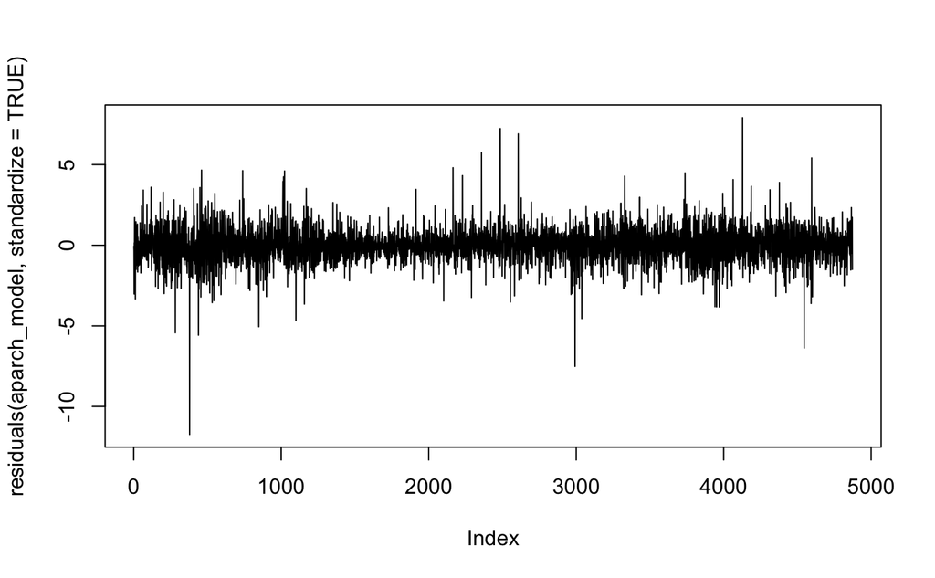

```r
plot(residuals(aparch_model, standardize = TRUE), type="l")
```

Figura 6 - Resíduos padronizados do modelo APARCH(2,0).

A figura 6 apresenta os resíduos padronizados ao longo da série e podemos notar a semelhança do seu formato com a de um ruído branco. Seguirei com a análise da autocorrelação deles.

```r
par(mfrow = c(1, 2), mar = c(6, 2, 6, 2))
acf(residuals(aparch_model, standardize = TRUE), main="ACF dos resíduos")
acf(residuals(aparch_model, standardize = TRUE)^2, main="ACF dos resíduos ao quadrado")
```

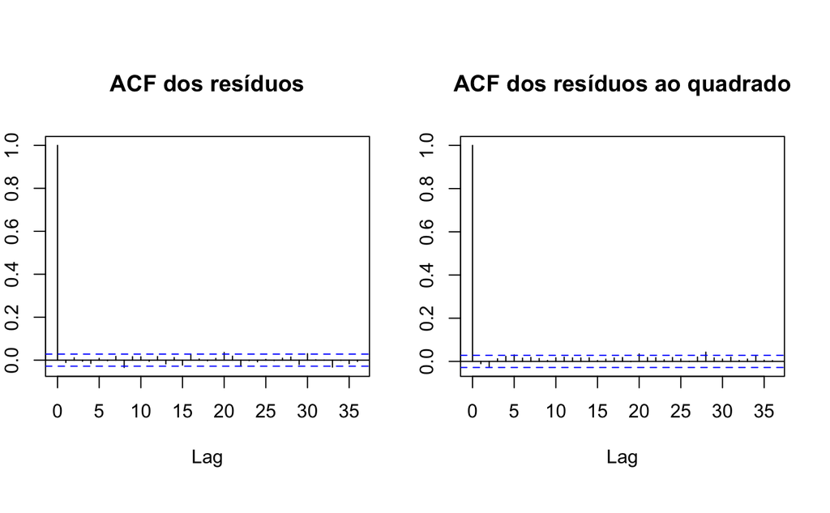

```r
par(mfrow = c(1, 1))
```

Figura 7 - Gráficos da função de autocorrelação para os resíduos padronizados (as-is e ao quadrado) do modelo APARCH(2,0).

A figura 7 apresenta os gráficos da função de autocorrelação dos resíduos padroni- zados do modelo para o valor as-is quanto ao quadrado. Espera-se que os valores de lag mantenham-se contidos dentro do intervalo de confiança apresentado.

Tanto no primeiro quanto no segundo quadrante notamos que os valores seguem essa premissa, com poucos lags sendo considerados relevantes. Como informado anterior- mente, o tamanho do conjunto de dados analisado afeta diretamente no quão estrei- to o intervalo pode ficar.

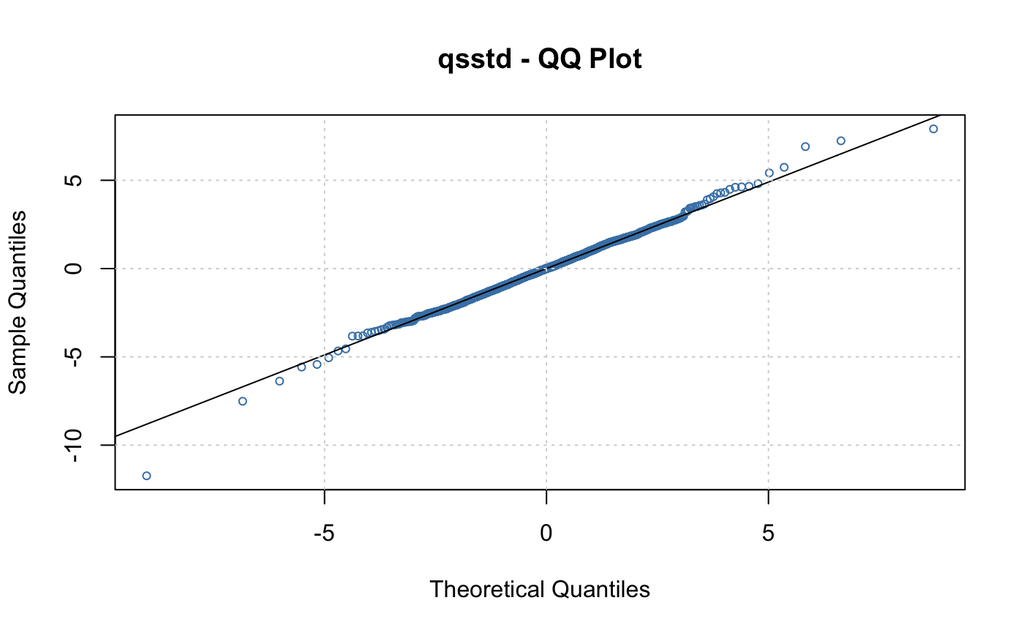

```r
plot(aparch_model, which = 13)
```

Figura 8 - QQplot dos resíduos do modelo APARCH(2,0).

Por fim, vemos na figura 8 que os resíduos seguem a distribuição condicional t-student padronizada e assimétrica.

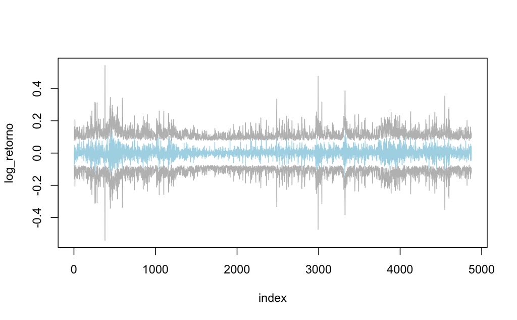

```r
ci <- 1.96

predicted_value <- fitted(aparch_model)
se <- fGarch::volatility(aparch_model)

upper_bound <- predicted_value + (2 * ci) * se
lower_bound <- predicted_value - (2 * ci) * se

ts.plot(ts(lr), ts(upper_bound), ts(lower_bound), xlab="index", ylab="log_retorno", lty=c(1,1,1), col=c("lightblue", "gray", "gray"))
```